# Research Problem.

Research objective: To investigate that, taking control variables into account, which type of vaccination promotion messages, compared to control (i.e., no exposure) condition, predicts vaccination intention most effectively, especially among people with conspiracy beliefs.

The data was run with a inferential statistic with general linear regression modeling. However, its R2 was low yet significant. In addition, its raw data appears to be curvy. Therefore, I am expecting to see if non-linear modeling would fit the data better. The potential benefits of having this new predictive model could contribute to the new method in persuading conspiracists to get more vaccination.

# Description of the data and variables.

This data is retrieved from an online experimental study. The original study is designed to investigate the moderated mediation model with a single outcome. The details of the variables are detailed below: # - Predictor (categorical with 4 levels): Types of messages (Conditions) # - Moderator (all continuous): General Conspiracy Belief (GenConBlf), Vaccine Conspiracy Belief (VacConBlf) # - Outcome (continuous): Vaccination Intention (VacIntMMR) # - Mediators (continuous): Affect toward MMR vaccine (Aff_MMR), perceived risk toward Measle (RskMsl), Perceived risk toward MMR vaccine (RskMMRVac), perceived benefit toward MMR vaccine (BnfMmrVac), MMR Vaccine hesitancy: inconfidence (HstMMR_Inconfidence), MMR vaccine hesitance: risk (HstMMR_risk), attitude toward MMR vaccine (AttdMMRVac), attitude toward Measles (AttdMeasles) # - Control variables # o Categorical variables: Gender, Ethnicity, Race, marital status (marital), Career (Employ) # o Continuous variables: Political Ideology(PolIdeo), age, number of children (ChildNum), Income, Education (Edu)

# Description of the models

```r
  require(caret)
  require(recipes)
  require(finalfit)
  require(glmnet)
  require(vip)
  require(cutpointr)
  require(ffglimps)
  require(dplyr)
  require(tidyverse)
  require(ranger)
```

Download & Clean the Dataset

```r
data = read.csv("https://urldefense.com/v3/__https:/raw.githubusercontent.com/Ping-Wongphothiphan/ML-Datafile/main/dissetation*20data.csv__;JQ!!C5qS4YX3!R1UFAiEhkRYW_BIh0ElD_ivlZf_oR8Cx-y26VoXRp_bZjrcV9rFQ-J2G1XlWzv3KGGU$", header = TRUE)

summary(data)
```

```
##    GenConBlf       VacConBlf     InfoPros_Analytic InfoPros_Experiential
##  Min.   :1.000   Min.   :1.000   Min.   :1.800     Min.   :1.000
##  1st Qu.:3.000   1st Qu.:3.143   1st Qu.:4.600     1st Qu.:2.200
##  Median :3.533   Median :3.714   Median :5.400     Median :3.000
##  Mean   :3.461   Mean   :3.638   Mean   :5.294     Mean   :3.172
##  3rd Qu.:3.933   3rd Qu.:4.143   3rd Qu.:6.000     3rd Qu.:4.000
##  Max.   :5.000   Max.   :5.000   Max.   :7.000     Max.   :6.400
##
##     Aff_MMR         Aff_Cov          RskMsl          RskCov
##  Min.   :1.000   Min.   :1.000   Min.   :1.000   Min.   :1.000
##  1st Qu.:2.000   1st Qu.:2.000   1st Qu.:3.000   1st Qu.:3.000
##  Median :4.000   Median :3.000   Median :3.000   Median :4.000
##  Mean   :3.259   Mean   :2.801   Mean   :3.392   Mean   :3.539
##  3rd Qu.:4.000   3rd Qu.:4.000   3rd Qu.:4.000   3rd Qu.:5.000
##  Max.   :5.000   Max.   :5.000   Max.   :5.000   Max.   :5.000
##                                  NA's   :1       NA's   :1
##    RskMmrVac       RskCovVac       BnfMmrVac       BnfCovVac
##  Min.   :1.000   Min.   :1.000   Min.   :1.000   Min.   :1.000
##  1st Qu.:2.000   1st Qu.:3.000   1st Qu.:3.000   1st Qu.:2.000
##  Median :3.000   Median :3.000   Median :3.000   Median :3.000
##  Mean   :2.817   Mean   :3.283   Mean   :3.228   Mean   :2.812
##  3rd Qu.:3.000   3rd Qu.:4.000   3rd Qu.:4.000   3rd Qu.:4.000
##  Max.   :5.000   Max.   :5.000   Max.   :5.000   Max.   :5.000
##                  NA's   :2       NA's   :3
##    VacIntMMR     VacIntCOV_Child VacIntCOV_Self  HstMMR_inconfidence
##  Min.   :1.000   Min.   :1.000   Min.   :1.000   Min.   :1.000
##  1st Qu.:2.500   1st Qu.:2.000   1st Qu.:2.000   1st Qu.:1.857
##  Median :3.500   Median :3.000   Median :3.000   Median :2.429
##  Mean   :3.267   Mean   :2.797   Mean   :2.806   Mean   :2.515
##  3rd Qu.:4.000   3rd Qu.:4.000   3rd Qu.:4.000   3rd Qu.:3.000
##  Max.   :5.000   Max.   :5.000   Max.   :5.000   Max.   :5.000
##                  NA's   :1       NA's   :1       NA's   :2
##   HstMMR_risk     HstCov_risk    HstCov_inconfidence   AttdMMRVac
##  Min.   :1.000   Min.   :1.000   Min.   :1.000       Min.   :1.667
##  1st Qu.:3.000   1st Qu.:3.000   1st Qu.:2.143       1st Qu.:2.667
##  Median :3.500   Median :3.500   Median :2.857       Median :3.000
##  Mean   :3.379   Mean   :3.594   Mean   :2.934       Mean   :3.083
##  3rd Qu.:4.000   3rd Qu.:4.000   3rd Qu.:3.536       3rd Qu.:3.500
##  Max.   :5.000   Max.   :5.000   Max.   :5.000       Max.   :4.833
##  NA's   :2       NA's   :3       NA's   :3           NA's   :3
```

[output cut: 25 more lines]

```
##  Min.   :1.000   Min.   :1.000   Min.   :1.000   Min.   :1.000
##  1st Qu.:1.000   1st Qu.:2.000   1st Qu.:1.000   1st Qu.:1.000
##  Median :2.000   Median :3.000   Median :1.000   Median :1.000
##  Mean   :1.991   Mean   :2.606   Mean   :1.808   Mean   :1.627
##  3rd Qu.:3.000   3rd Qu.:3.000   3rd Qu.:1.000   3rd Qu.:2.000
##  Max.   :4.000   Max.   :5.000   Max.   :5.000   Max.   :6.000
##  NA's   :8       NA's   :8       NA's   :9       NA's   :8
##      Income            Edu            Employ          States
##  Min.   : 1.000   Min.   :1.000   Min.   :1.000   Min.   : 1.00
##  1st Qu.: 3.000   1st Qu.:4.000   1st Qu.:6.000   1st Qu.: 9.00
##  Median : 6.000   Median :5.000   Median :6.000   Median :22.00
##  Mean   : 5.766   Mean   :4.683   Mean   :5.709   Mean   :22.38
##  3rd Qu.: 8.000   3rd Qu.:5.000   3rd Qu.:6.000   3rd Qu.:35.00
##  Max.   :12.000   Max.   :8.000   Max.   :9.000   Max.   :49.00
##  NA's   :9        NA's   :8       NA's   :11      NA's   :10
```

Some unrelated were deleted.

```r
data <- data %>% select(-InfoPros_Analytic, -InfoPros_Experiential, -Aff_Cov, -RskCov, -RskCovVac, -BnfCovVac, -VacIntCOV_Child, -VacIntCOV_Self, -HstCov_risk, -HstCov_inconfidence, -AttdCovVac, -AttdCov19, -SbjNrmMMR, -BhvCtrlMMR, -SbjNrmCov, -BhvCtrlCov, -SlfPolIdeo, -States)

summary(data)
```

```
##    GenConBlf       VacConBlf        Aff_MMR          RskMsl
##  Min.   :1.000   Min.   :1.000   Min.   :1.000   Min.   :1.000
##  1st Qu.:3.000   1st Qu.:3.143   1st Qu.:2.000   1st Qu.:3.000
##  Median :3.533   Median :3.714   Median :4.000   Median :3.000
##  Mean   :3.461   Mean   :3.638   Mean   :3.259   Mean   :3.392
##  3rd Qu.:3.933   3rd Qu.:4.143   3rd Qu.:4.000   3rd Qu.:4.000
##  Max.   :5.000   Max.   :5.000   Max.   :5.000   Max.   :5.000
##                                                  NA's   :1
##    RskMmrVac       BnfMmrVac       VacIntMMR     HstMMR_inconfidence
##  Min.   :1.000   Min.   :1.000   Min.   :1.000   Min.   :1.000
##  1st Qu.:2.000   1st Qu.:3.000   1st Qu.:2.500   1st Qu.:1.857
##  Median :3.000   Median :3.000   Median :3.500   Median :2.429
##  Mean   :2.817   Mean   :3.228   Mean   :3.267   Mean   :2.515
##  3rd Qu.:3.000   3rd Qu.:4.000   3rd Qu.:4.000   3rd Qu.:3.000
##  Max.   :5.000   Max.   :5.000   Max.   :5.000   Max.   :5.000
##                  NA's   :3                       NA's   :2
##   HstMMR_risk      AttdMMRVac     AttdMeasles      Condition
##  Min.   :1.000   Min.   :1.667   Min.   :1.000   Min.   :0.000
##  1st Qu.:3.000   1st Qu.:2.667   1st Qu.:3.000   1st Qu.:1.000
##  Median :3.500   Median :3.000   Median :3.600   Median :2.000
##  Mean   :3.379   Mean   :3.083   Mean   :3.468   Mean   :1.513
##  3rd Qu.:4.000   3rd Qu.:3.500   3rd Qu.:4.000   3rd Qu.:3.000
##  Max.   :5.000   Max.   :4.833   Max.   :5.000   Max.   :3.000
##  NA's   :2       NA's   :3       NA's   :3
##      Gender        Ethnicity          Race          PolIdeo
##  Min.   :1.000   Min.   :1.000   Min.   :1.000   Min.   :1.000
##  1st Qu.:1.000   1st Qu.:2.000   1st Qu.:1.000   1st Qu.:2.000
##  Median :1.000   Median :2.000   Median :1.000   Median :3.000
##  Mean   :1.495   Mean   :1.811   Mean   :2.009   Mean   :2.855
##  3rd Qu.:2.000   3rd Qu.:2.000   3rd Qu.:3.000   3rd Qu.:4.000
##  Max.   :5.000   Max.   :2.000   Max.   :7.000   Max.   :5.000
##  NA's   :9       NA's   :14      NA's   :8       NA's   :8
##       age           marital         ChildNum         Income
##  Min.   :1.000   Min.   :1.000   Min.   :1.000   Min.   : 1.000
##  1st Qu.:2.000   1st Qu.:1.000   1st Qu.:1.000   1st Qu.: 3.000
##  Median :3.000   Median :1.000   Median :1.000   Median : 6.000
##  Mean   :2.606   Mean   :1.808   Mean   :1.627   Mean   : 5.766
##  3rd Qu.:3.000   3rd Qu.:1.000   3rd Qu.:2.000   3rd Qu.: 8.000
##  Max.   :5.000   Max.   :5.000   Max.   :6.000   Max.   :12.000
##  NA's   :8       NA's   :9       NA's   :8       NA's   :9
##       Edu            Employ
##  Min.   :1.000   Min.   :1.000
##  1st Qu.:4.000   1st Qu.:6.000
##  Median :5.000   Median :6.000
##  Mean   :4.683   Mean   :5.709
##  3rd Qu.:5.000   3rd Qu.:6.000
##  Max.   :8.000   Max.   :9.000
##  NA's   :8       NA's   :11
```

Recode lables of categorical variables.

```r
data$Condition <- recode(data$Condition, "0" = "control", "1" = "fact", "2" = "narrative", "3" = "hybrid")

data$Gender <- recode(data$Gender, "1" = "Male", "2"="Female", "3" = "Non-binary", "4" = "Prefer not to say", "5"="Other")

data$Ethnicity <- recode(data$Ethnicity, "1"="Hispanic", "2"="Non-Hispanic")

data$Race <- recode(data$Race, "1"="white", "2"="Black", "3"="Native American", "4" ="Asian", "5" = "Pacific Islander", "6" = "Two or more", "7" = "Other")

data$PolIdeo <- recode(data$PolIdeo, "1"="very conservative", "2" = "conservative", "3" = "neutral", "4" ="liberal", "5" = "very liberal")

data$marital <- recode(data$marital, "1" = "married", "2" = "widowed", "3" = "divorced", "4"="separated", "5"="partnered")

data$age <- recode(data$age, "1" = "18-20", "2" = "21-30", "3"="31-40", "4"="41-50", "5"="51-60", "6"= "61-70", "7" = "70+")

data$ChildNum <- recode(data$ChildNum, "1"="1", "2"="2","3"="3","4"="4","5"="5","6"="more than 5")

data$Income <- recode(data$Income, "1"="Less than $10,000", "2" = "$10,000 - $19,999", "3" = "$20,000 - $29,999", "4" = "$30,000 - $39,999", "5"="$40,000 - $49,999", "6"="$50,000 - $59,999", "7" = "$60,000 - $69,999", "8"="$70,000 - $79,999", "9" = "$80,000 - $89,999", "10" = "$90,000 - $99,999", "11"="$100,000 - $149,999", "12" = "More than $150,000")

data$Edu <- recode(data$Edu, "1"="Less than a high school diploma", "2"="High school degree", "3"="Some college, no degree", "4"="Associate degree", "5"="Bachelor's degree", "6"="Master's degree", "7"="Professional degree", "8" ="Doctorate")

data$Employ <- recode(data$Employ, "1" = "student", "2" = "retired", "3" = "homemaker", "4"="self-efployed", "5"="unable to work", "6" = "employed full time", "7" = "employed part time", "8" = "Unemployed, looking for work", "9" = "unemployed, not looking for work")
```

Assign categorical variables.

```r
data$Condition <- as.factor(data$Condition)
data$Gender <- as.factor(data$Gender)
data$Ethnicity <- as.factor(data$Ethnicity)
data$Race <- as.factor(data$Race)
data$marital <- as.factor(data$marital)
data$Employ <- as.factor(data$Employ)
data$Edu <- as.factor(data$Edu)
data$Income <- as.factor(data$Income)
data$ChildNum <- as.factor(data$ChildNum)
data$age <- as.factor(data$age)
data$PolIdeo <- as.factor(data$PolIdeo)
```

Check missingness

```r
ff_glimpse(data)$Continuous[,c("n","missing_percent")]
```

```
##                       n missing_percent
## GenConBlf           437             0.0
## VacConBlf           437             0.0
## Aff_MMR             437             0.0
## RskMsl              436             0.2
## RskMmrVac           437             0.0
## BnfMmrVac           434             0.7
## VacIntMMR           437             0.0
## HstMMR_inconfidence 435             0.5
## HstMMR_risk         435             0.5
## AttdMMRVac          434             0.7
## AttdMeasles         434             0.7
```

```r
ff_glimpse(data)$Categorical[,c("n","missing_percent")]
```

```
##             n missing_percent
## Condition 437             0.0
## Gender    428             2.1
## Ethnicity 423             3.2
## Race      429             1.8
## PolIdeo   429             1.8
## age       429             1.8
## marital   428             2.1
## ChildNum  429             1.8
## Income    428             2.1
## Edu       429             1.8
## Employ    426             2.5
```

Neither of the variables has more than 80% missingness.

Split Training and Testing datasets, 90:10, and create 10-fold crossvalidation

```r
set.seed(124830)

#Split data
loc <- sample(1:nrow(data), round(nrow(data)*0.9))
data_tr <- data[loc, ]
data_te <- data[-loc, ]

#Randomly shuffle the data
data_tr = data_tr[sample(nrow(data_tr)),]

#create 10-fold cross validation
folds = cut(seq(1,nrow(data_tr)), breaks = 10, labels = FALSE)

my.indices <- vector("list", 10)
for(i in 1:10){
  my.indices[[i]] <- which(folds!=i)
}
cv <- trainControl(method = "cv",
                   index = my.indices)
```

Create blueprint using “recipes” package

Put variables into groups

```r
outcome <- c("VacIntMMR")
categorical <- c("Condition", "Gender", "Ethnicity", "Race", "marital", "Employ", "PolIdeo", "age", "ChildNum", "Income", "Edu")
numeric <- c("GenConBlf", "VacConBlf", "Aff_MMR", "RskMsl", "RskMmrVac", "BnfMmrVac", "HstMMR_inconfidence", "HstMMR_risk", "AttdMMRVac", "AttdMeasles")
```

Create blueprint

```r
blueprint <- recipe(x = data,
                   vars = c(categorical, numeric, outcome),
                   roles = c(rep("predictor",21), "outcome")) %>%
  step_indicate_na(all_of(categorical), all_of(numeric))%>%
  step_zv(all_of(numeric)) %>%
  step_impute_mean(all_of(numeric)) %>%
  step_impute_mode(all_of(categorical)) %>%
  step_ns(all_of(numeric), deg_free = 4) %>%
  step_normalize(paste0(numeric, "_ns_1"),
                 paste0(numeric, "_ns_2"),
                 paste0(numeric, "_ns_3"),
                 paste0(numeric, "_ns_4")) %>%
  step_dummy(all_of(categorical), one_hot = TRUE)

blueprint
```

```
## Recipe
##
## Inputs:
##
##       role #variables
##    outcome          1
##  predictor         21
##
## Operations:
##
## Creating missing data variable indicators for all_of(categorical), all_of(numeric)
## Zero variance filter on all_of(numeric)
## Mean Imputation for all_of(numeric)
## Mode Imputation for all_of(categorical)
## Natural Splines on all_of(numeric)
## Centering and scaling for paste0(numeric, "_ns_1"), paste0(numeric, "_ns_...
## Dummy variables from all_of(categorical)
```

# Model 1: General Linear Regression Model

Train the model

```r
LinReg_mod <- caret::train(blueprint,
                           data = data_tr,
                           method = "lm",
                           trControl = cv)
LinReg_mod
```

```
## Linear Regression
##
## 393 samples
##  21 predictor
##
## Recipe steps: indicate_na, zv, impute_mean, impute_mode, ns, normalize, dummy
## Resampling: Cross-Validated (10 fold)
## Summary of sample sizes: 353, 354, 354, 354, 353, 354, ...
## Resampling results:
##
##   RMSE       Rsquared  MAE
##   0.8721967  0.501425  0.6710738
##
## Tuning parameter 'intercept' was held constant at a value of TRUE
```

Applying testing set to the model

```r
LinReg_data_te <- predict(LinReg_mod, data_te)
```

Evaluate model performance of General Linear Regression

```r
rsq_LinReg_te <- cor(data_te$VacIntMMR, LinReg_data_te)^2
mae_LinReg_te <- mean(abs(data_te$VacIntMMR - LinReg_data_te))
rmse_LinReg_te <- sqrt(mean((data_te$VacIntMMR - LinReg_data_te)^2))

rsq_LinReg_te
```

```
## [1] 0.2752489
```

```r
mae_LinReg_te
```

```
## [1] 0.7038368
```

```r
rmse_LinReg_te
```

```
## [1] 0.910369
```

Investigate the most important 15 predictors

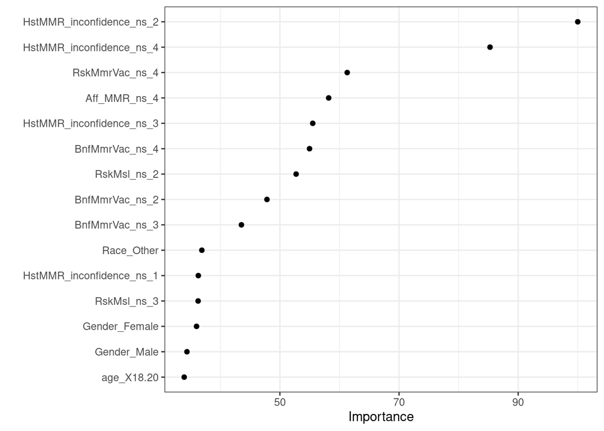

```r
vip(LinReg_mod, num_features = 15, geom = "point")+
  theme_bw()
```

# Model 2: Regression Model with Ridge Penalty

Tune grid for Ridge penalty

```r
grid_ridge <- data.frame(alpha = 0, lambda = seq(0.45, 0.50, .001))
```

Train the model

```r
Ridge_mod <- caret::train(blueprint,
                           data = data_tr,
                           method = "glmnet",
                           trControl = cv,
                           tuneGrid = grid_ridge)
Ridge_mod$results
```

```
##    alpha lambda      RMSE  Rsquared       MAE    RMSESD RsquaredSD      MAESD
## 1      0  0.450 0.7622823 0.5690782 0.5995394 0.1173598 0.06142135 0.09793649
## 2      0  0.451 0.7622793 0.5690922 0.5995518 0.1173733 0.06141539 0.09796188
## 3      0  0.452 0.7622765 0.5691062 0.5995643 0.1173868 0.06140941 0.09798729
## 4      0  0.453 0.7622739 0.5691200 0.5995767 0.1174003 0.06140341 0.09801271
## 5      0  0.454 0.7622714 0.5691339 0.5995892 0.1174137 0.06139739 0.09803816
## 6      0  0.455 0.7622691 0.5691476 0.5996016 0.1174270 0.06139134 0.09806361
## 7      0  0.456 0.7622670 0.5691613 0.5996140 0.1174404 0.06138528 0.09808909
## 8      0  0.457 0.7622650 0.5691748 0.5996265 0.1174537 0.06137919 0.09811458
## 9      0  0.458 0.7622632 0.5691884 0.5996389 0.1174669 0.06137308 0.09814009
## 10     0  0.459 0.7622615 0.5692018 0.5996514 0.1174802 0.06136696 0.09816561
## 11     0  0.460 0.7622601 0.5692152 0.5996638 0.1174934 0.06136081 0.09819116
## 12     0  0.461 0.7622588 0.5692285 0.5996762 0.1175065 0.06135464 0.09821672
## 13     0  0.462 0.7622576 0.5692417 0.5996887 0.1175197 0.06134844 0.09824229
## 14     0  0.463 0.7622566 0.5692548 0.5997011 0.1175328 0.06134223 0.09826788
```

[output cut: 37 more lines]

```r
Ridge_mod$bestTune
```

```
##    alpha lambda
## 19     0  0.468
```

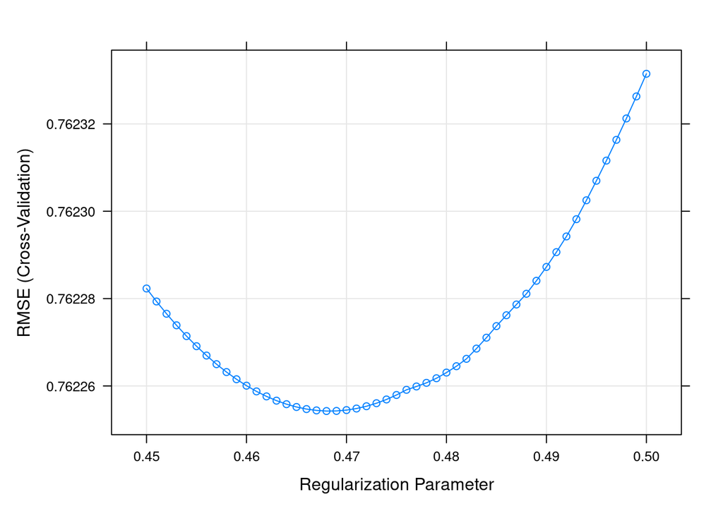

```r
plot(Ridge_mod)
```

Apply the testing set to Linear Regression with Ridge penalty

```r
Ridge_data_te <- predict(Ridge_mod, data_te)
```

```r
rsq_Ridge_te <- cor(data_te$VacIntMMR, Ridge_data_te)^2
mae_Ridge_te <- mean(abs(data_te$VacIntMMR - Ridge_data_te))
rmse_Ridge_te <- sqrt(mean((data_te$VacIntMMR - Ridge_data_te)^2))

rsq_Ridge_te
```

```
## [1] 0.3719112
```

```r
mae_Ridge_te
```

```
## [1] 0.608306
```

```r
rmse_Ridge_te
```

```
## [1] 0.8069589
```

Let’s see if the 15 important predictors are the same

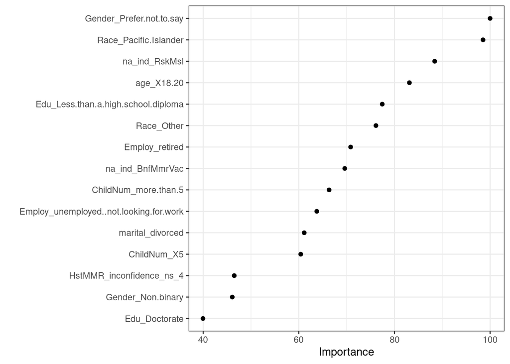

```r
vip(Ridge_mod, num_features = 15, geom = "point")+
  theme_bw()
```

# Model 3: Bagged Tree Model

Tune grid

```r
grid_bagged_tr <- expand.grid(mtry = 129, splitrule = "variance", min.node.size = 2)
```

```r
# I will create the model with 500 trees.
      bagged_mod <- caret::train(blueprint,
                                data      = data_tr,
                                method    = 'ranger',
                                trControl = cv,
                                tuneGrid  = grid_bagged_tr,
                                num.trees = 500,
                                max.depth = 60)
```

Apply the testing set to the Bagged Tree Model with 500 trees.

```r
Bagged_data_te <- predict(bagged_mod,data_te)

mae_bagged_te <- mean(abs(data_te$VacIntMMR - Bagged_data_te))
rmse_bagged_te <- sqrt(mean((data_te$VacIntMMR - Bagged_data_te)^2))
rsq_bagged_te <- cor(data_te$VacIntMMR, Bagged_data_te)^2

rsq_bagged_te
```

```
## [1] 0.3870294
```

```r
mae_bagged_te
```

```
## [1] 0.5891364
```

```r
rmse_bagged_te
```

```
## [1] 0.8166103
```

# Model 4: Random Forest

Setting up grid for Random Forest model

```r
    grid_rdmforest <- expand.grid(mtry = 43,
                        splitrule='variance',
                        min.node.size=2)
```

Grow Random forest with 500 trees.

```r
      rdmforest_mod <- caret::train(blueprint,
                                data      = data_tr,
                                method    = 'ranger',
                                trControl = cv,
                                tuneGrid  = grid_rdmforest,
                                num.trees = 500,
                                max.depth = 60)
```

Predict the testing set

```r
rdmforest_data_te <- predict(rdmforest_mod, data_te)
```

```r
mae_rdmforest_te <- mean(abs(data_te$VacIntMMR - rdmforest_data_te))
rmse_rdmforest_te <- sqrt(mean((data_te$VacIntMMR - rdmforest_data_te)^2))
rsq_rdmforest_te <- cor(data_te$VacIntMMR, rdmforest_data_te)^2

rsq_rdmforest_te
```

```
## [1] 0.3804617
```

```r
mae_rdmforest_te
```

```
## [1] 0.5798864
```

```r
rmse_rdmforest_te
```

```
## [1] 0.8130485
```

Model Performance Evaluation

[output not shown]

# Discussion/Conclusion

In general linear regression model, compared to the training model, R-square value of the testing set drops significantly from .50 to .27. This suggest overfitting. However, RMSE and MAE values of the testing set slightly increase from 0.87 to 0.91 and from 0.67 to 0.70, respectively. The important predictors of this models include vaccine hesitancy, perceived risk toward MMR, affect toward MMR vaccine, perceived benefits toward MMR vaccine, percieved risks toward Measles, Race_other, being a male, being a female, and being 18-20 y-o.

For linear regression model with ridge penalty, in the testing set, R-sq significantly drops from those in the training dataset from 0.57 to 0.37. This significant drop suggests overfitting in the training model. However, RMSE in the training set increase for only 0.05, while MAE is barely changed. Interestingly, the order of variable importance has changed siginificantly. So many demographic characteristics shows up as important predictors after Ridge penalty. For example, being a pacific islander, missin values of percieved risks toward measles and perceived benefits toward MMR vaccine, having more than 5 childrend, being divorced, retired and unemployed, and being non-heterosexual participants. Being 18-20 y-o was ranked as the 15th importance in general linear regression model, but switched up to be the 4th important vaariable in regression model with ridge penalty.

General Linear Regression Model without any penalty perform worst, compared to others. However the General Linear Regression Model did not perform above and beyond Random Forest Model.

Unsurprisingly, my original predictor in the experiment (types of messages) did not show up in the top 15 of important variables. It is known that simply one-time exposure to a message does not powerful enough to change individual attitudes, especially thosw with a strong attitude toward a particular issue. However, I’m glad to know that there are some demographic variables that significantly predict my outcome variable. This suggests me to further investigate in my dissertation.